# Detekcija loših StackOverflow pitanja

September 17, 2018

## Zadatak

- Zadatak je da se oceni da li je neko pitanje sa http://stackoverflow.com loše ili ne.
- Kao meru kvaliteta pitanja koristimo “score” pitanja, što predstavlja razliku u pozitivnim i negativnim glasovima koje su pitanju dodelili ćlanovi.
- Pitanje smatramo lošim ako ima (strogo) negativan skor, a dobrim ako ima (strogo) pozitivan skor

## Podaci

- Podaci koji su korišćeni su sva pitanja na StackOverflow-u od 01.01.2016 do danas.
- Preuzeti sa https://archive.org/details/stackexchange
- Raspodela klasa pitanja (loše, nula, dobro), u brojevima (za 2016. god.):
  - Loše: 195,733
  - Nula: 1,072,209
  - Dobro: 955,376
  - (ukupno) 2,223,318

## Raspodela podataka

Raspodela podataka po klasama: loše, nula, dobro:

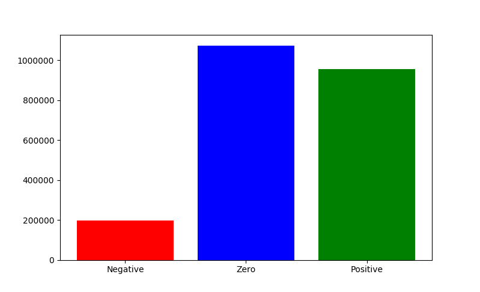

## Podaci

- Dva problema:
  1. Nule čine skoro polovinu svih podataka
  2. Neizbalansiranost klasa \(\left(\frac{|loša\ pitanja|}{|dobra\ pitanja|}\approx 0.2\right)\)
- Rešenja:
  1. Jer ne nose nikakvu informaciju o kvalitetu pitanja, a unose velik šum, izbacujemo nule iz podataka.
  2. Koristimo modele koji uzimaju u obzir neizbalansiranost klasa.

## Model

- Konačan model je u dva nivoa.
- Prvi sloj: Dva modela koji, koristeći Word2Vec reprezentacije reči u tekstu, na osnovu teksta pitanja i naslova pitanja predviđaju verovatnoću da je pitanje loše. Algoritam korišćen nad vektorskim reprezentacijama tekstova (prosek reprezentacija reči) je `BalancedBaggingClassifier` iz `imblearn` paketa, zbog neizbalansiranosti klasa.
- Drugi sloj: Logistička regresija sa atributima sačinjenim od predviđanja dobijenih iz prethodnog sloja, sa dodatkom prostijih atributa poput dužine pitanja, reputacije korisnika, kao i kosinusnog rastojanja reprezentacija naslova i tela pitanja.

## Obučavanje

- Prvi sloj - W2V model i klasifikatori obučavani na pitanjima iz 2016. god. i pitanjima iz prvog kvartala 2017. (2016. za obuč. + 1. q. 2017 za val.)
- Drugi sloj - logistička regresija obučavana na preostala 3 (2 za obuč. + 1 za val.) kvartala 2017. godine.
- Prva polovina 2018. ostavljena za testiranje
- Rezultati konačnog modela:
  - AUC: 0.7453
  - za prag 0.275 (odabran u aplikaciji):
    - Precision: 0.46, Recall: 0.57, F1 score: 0.51
- Fun fact - svo obučavanje rađeno na Google Compute Engine instanci sa 24 vCPU i 100GB ram memorije, zbog veličine podataka i modela.

## Aplikacija

- Napravljena je Downvoter aplikacija koja ocenjuje pitanja na SO. Nalazi se na http://downvoter.duckdns.org:8387 (pokreće se na zahtev)
- Kod aplikacije, kao i skripti za model je na Github repozitorijumu https://github.com/blaza/downvoter
- Neka pitanja za testiranje:
  - https://stackoverflow.com/questions/52264638 (ne voli decu)
  - https://stackoverflow.com/questions/52113522 (voli c++)
  - https://stackoverflow.com/questions/52237695 (i haskell)
  - https://stackoverflow.com/questions/52344972 (petlje su bezveze)
  - https://stackoverflow.com/questions/9083037 (P1 ga ne impresionira)
  - https://stackoverflow.com/questions/52344832 (razlog za disbalans između klasa)

## Slike aplikacije

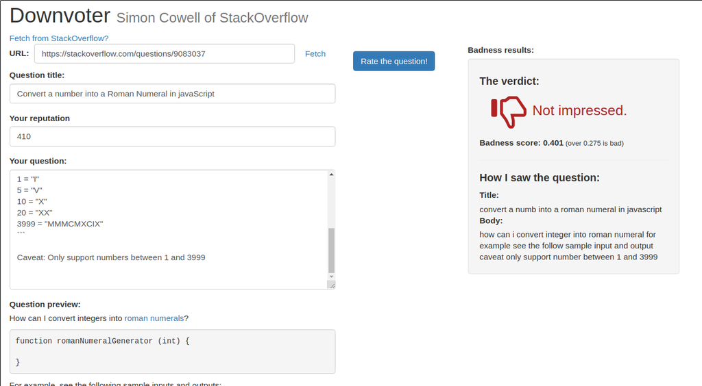

## Slike aplikacije

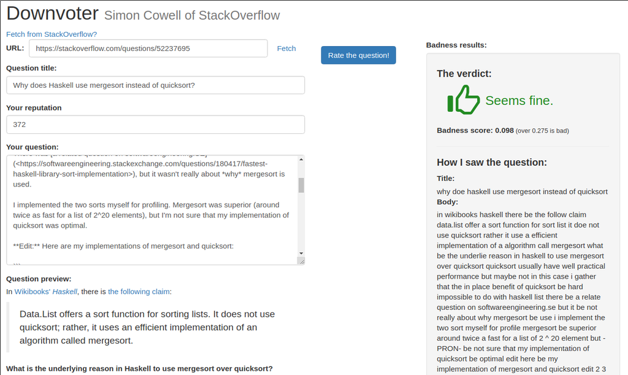